# Project Foundations for Data Science: FoodHub Data Analysis

**Marks: 40**

### Context

The number of restaurants in New York is increasing day by day. Lots of students and busy professionals rely on those restaurants due to their hectic lifestyles. Online food delivery service is a great option for them. It provides them with good food from their favorite restaurants. A food aggregator company FoodHub offers access to multiple restaurants through a single smartphone app.

The app allows the restaurants to receive a direct online order from a customer. The app assigns a delivery person from the company to pick up the order after it is confirmed by the restaurant. The delivery person then uses the map to reach the restaurant and waits for the food package. Once the food package is handed over to the delivery person, he/she confirms the pick-up in the app and travels to the customer's location to deliver the food. The delivery person confirms the drop-off in the app after delivering the food package to the customer. The customer can rate the order in the app. The food aggregator earns money by collecting a fixed margin of the delivery order from the restaurants.

### Objective

The food aggregator company has stored the data of the different orders made by the registered customers in their online portal. They want to analyze the data to get a fair idea about the demand of different restaurants which will help them in enhancing their customer experience. Suppose you are hired as a Data Scientist in this company and the Data Science team has shared some of the key questions that need to be answered. Perform the data analysis to find answers to these questions that will help the company to improve the business.

### Data Description

The data contains the different data related to a food order. The detailed data dictionary is given below.

### Data Dictionary

- order_id: Unique ID of the order
- customer_id: ID of the customer who ordered the food
- restaurant_name: Name of the restaurant
- cuisine_type: Cuisine ordered by the customer
- cost: Cost of the order
- day_of_the_week: Indicates whether the order is placed on a weekday or weekend (The weekday is from Monday to Friday and the weekend is Saturday and Sunday)
- rating: Rating given by the customer out of 5
- food_preparation_time: Time (in minutes) taken by the restaurant to prepare the food. This is calculated by taking the difference between the timestamps of the restaurant's order confirmation and the delivery person's pick-up confirmation.
- delivery_time: Time (in minutes) taken by the delivery person to deliver the food package. This is calculated by taking the difference between the timestamps of the delivery person's pick-up confirmation and drop-off information

### Let us start by importing the required libraries

```python
# import libraries for data manipulation
import numpy as np
import pandas as pd

# import libraries for data visualization
import matplotlib.pyplot as plt
import seaborn as sns
```

### Understanding the structure of the data

```python
# uncomment and run the following lines for Google Colab
from google.colab import drive
drive.mount('/content/drive')
```

```python
# read the data
path = "foodhub_order.csv"
df = pd.read_csv(path)
# returns the first 5 rows
df.head()
```

|  | order_id | customer_id | restaurant_name | cuisine_type | cost_of_the_order | day_of_the_week | rating | food_preparation_time | delivery_time |
| --- | --- | --- | --- | --- | --- | --- | --- | --- | --- |
| 0 | 1477147 | 337525 | Hangawi | Korean | 30.75 | Weekend | Not given | 25 | 20 |
| 1 | 1477685 | 358141 | Blue Ribbon Sushi Izakaya | Japanese | 12.08 | Weekend | Not given | 25 | 23 |
| 2 | 1477070 | 66393 | Cafe Habana | Mexican | 12.23 | Weekday | 5 | 23 | 28 |
| 3 | 1477334 | 106968 | Blue Ribbon Fried Chicken | American | 29.20 | Weekend | 3 | 25 | 15 |
| 4 | 1478249 | 76942 | Dirty Bird to Go | American | 11.59 | Weekday | 4 | 25 | 24 |

#### Observations:

The DataFrame has 9 columns as mentioned in the Data Dictionary. Data in each row corresponds to the order placed by a customer.

### **Question 1:** How many rows and columns are present in the data?

```python
# Write your code here

df.shape
```

```
(1898, 9)
```

#### Observations: There are 9 columns as mentioned previously, and 1898 rows.

### **Question 2:** What are the datatypes of the different columns in the dataset? (The info() function can be used)

```python
# Use info() to print a concise summary of the DataFrame

df.info()
```

```
<class 'pandas.core.frame.DataFrame'>
RangeIndex: 1898 entries, 0 to 1897
Data columns (total 9 columns):
 #   Column                 Non-Null Count  Dtype
---  ------                 --------------  -----
 0   order_id               1898 non-null   int64
 1   customer_id            1898 non-null   int64
 2   restaurant_name        1898 non-null   object
 3   cuisine_type           1898 non-null   object
 4   cost_of_the_order      1898 non-null   float64
 5   day_of_the_week        1898 non-null   object
 6   rating                 1898 non-null   object
 7   food_preparation_time  1898 non-null   int64
 8   delivery_time          1898 non-null   int64
dtypes: float64(1), int64(4), object(4)
memory usage: 133.6+ KB
```

#### Observations: order_id, customer_id, food_preparation_time, and delivery_time are all integers. This means we will be dealing with whole numbers instead of floats for food prep time and delivery time. The cost_of_the_order is a float, which is to be expected. restaurant_name, cuisine_type, day_of_the_week, and rating are all objects, i.e. categorical variables. Despite being a number, it makes some sense that rating is a categorical variable rather than an integer, but we'll have to convert it to run statistics on it.

### **Question 3:** Are there any missing values in the data? If yes, treat them using an appropriate method

```python
# Find missing values

df.isnull().values.any()
```

```
False
```

#### Observations: The isnull() function shows that there are no null values, but this is to be expected after our info() function revealed that all the variables have the same number of non-null counts.

### **Question 4:** Check the statistical summary of the data. What is the minimum, average, and maximum time it takes for food to be prepared once an order is placed?

```python
# Write your code here

df.describe()
```

[output not shown]

```python
df.describe(include="object")
```

|  | restaurant_name | cuisine_type | day_of_the_week |
| --- | --- | --- | --- |
| count | 1898 | 1898 | 1898 |
| unique | 178 | 14 | 2 |
| top | Shake Shack | American | Weekend |
| freq | 219 | 584 | 1351 |

#### Observations: The food preparation time ranges from a minimum of 20 minutes to a maximum of 35 minutes, with a mean of ~27 and median of 27. The fact that that mean and median are so close and that they are both roughly equidistant from the min and max suggest that this variable has no outliers and that it may well be normally distributed.

#### The delivery time follows a similar distribution, while the order cost shows a bit wider spread and looks like it is a bit right-tailed.

### **Question 5:** How many orders are not rated?

```python
# Determine value counts for each order category

df["rating"].value_counts()
```

```
Not given    736
5            588
4            386
3            188
Name: rating, dtype: int64
```

#### Observations: 736 orders out of 1898 orders (38.7%) are not rated. Since 1 and 2 star ratings are not represented in the data, it may be that people tend not to leave ratings if their experience was quite bad and that some of the Not given ratings represent poor ratings, but that is speculation and not clear from the data. In my personal experience, people are more likely to leave bad ratings if they had a very negative experience, so the lack of 1 and 2 star ratings surprises me.

### Exploratory Data Analysis (EDA)

### **Question 6:** Explore all the variables and provide observations on their distributions. (Generally, histograms, boxplots, countplots, etc. are used for univariate exploration)

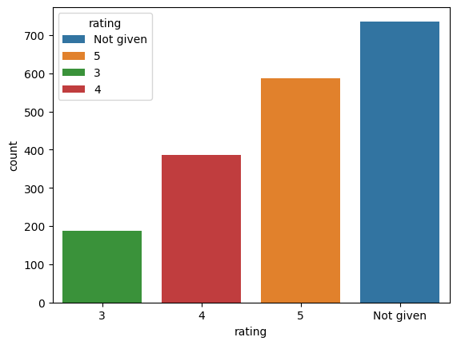

```python
# Create a countplot of the distribution of ratings

# Define the desired order of categories
order = ['3', '4', '5', 'Not given']
# Create the plot, setting 'hue' to 'rating' to handle the 'Not given' string
sns.countplot(data=df, x="rating", hue="rating", order=order, dodge=False)
plt.show()
```

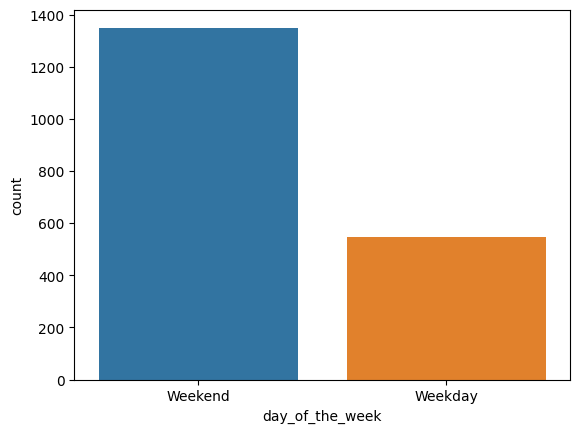

```python
# Create a countplot showing the number of orders on weekends and weekdays
sns.countplot(data=df, x="day_of_the_week")
plt.show()
```

Despite weekends only being two out of seven days of the week, there are about 2.5 times more orders on weekends than weekdays. This clearly shows that people order out much more often on weekends.

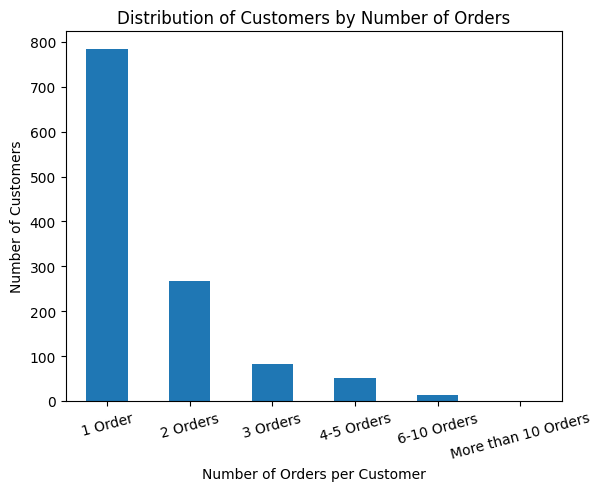

```python
# Map the distribution of customers based on number of orders they made

# Count the number of orders from each customer
customer_counts = df['customer_id'].value_counts()

# Create bins for categorizing customers based on number of orders
bins = [0, 1, 2, 3, 5, 10, float('inf')]

# Define bin labels
bin_labels = ['1 Order', '2 Orders', '3 Orders', '4-5 Orders', '6-10 Orders', 'More than 10 Orders']

# Categorize customers into bins
customer_counts_bin = pd.cut(customer_counts, bins, labels=bin_labels)

# Count the number of customers in each category
category_counts = customer_counts_bin.value_counts().reindex(bin_labels, fill_value=0)

# Create a bar plot of the categorized data
category_counts.plot(kind='bar', rot=15)

# Set plot labels and title
plt.xlabel('Number of Orders per Customer')
plt.ylabel('Number of Customers')
plt.title('Distribution of Customers by Number of Orders')
```

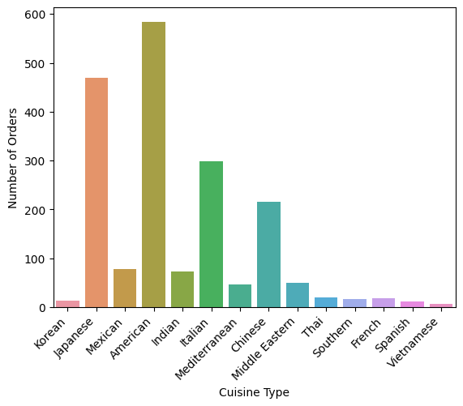

```python
# Create a count plot to show the frequency of different cuisine types
sns.countplot(data=df, x="cuisine_type")
plt.xlabel("Cuisine Type")
plt.ylabel("Number of Orders")
plt.xticks(rotation=45, ha='right')
plt.show()
```

This chart shows that, while there are 14 cuisine types represented in the data, the number of orders is dominated by a few types, with the most popular ones being 1) American, 2) Japanese, 3) Italian, and 4) Chinese. These types are ordered quite a lot more than the other cuisines.

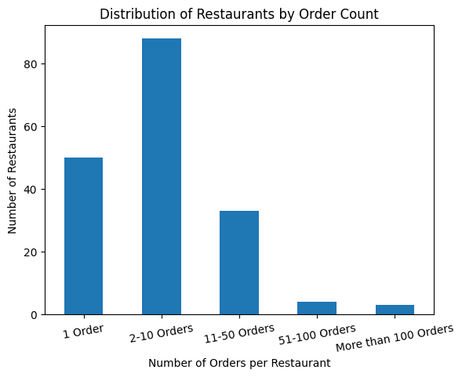

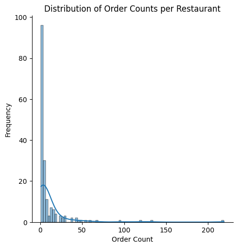

```python
# Here, I want to get a feel for the distribution of order numbers by restaurant.
#That is, I want to know whether the number of orders per restaurant is roughly evenly distributed, or dominated by a few major players.

# Count the number of orders for each restaurant
restaurant_counts = df['restaurant_name'].value_counts()

# Create bins for categorizing restaurants
bins = [0, 1, 10, 50, 100, float('inf')]

# Define bin labels
bin_labels = ['1 Order', '2-10 Orders', '11-50 Orders', '51-100 Orders', 'More than 100 Orders']

# Categorize restaurants into bins
restaurant_counts_bin = pd.cut(restaurant_counts, bins, labels=bin_labels)

# Count the number of restaurants in each category
category_counts = restaurant_counts_bin.value_counts().reindex(bin_labels, fill_value=0)

# Create a bar plot of the categorized data
category_counts.plot(kind='bar', rot=0)

# Set plot labels and title
plt.xlabel('Number of Orders per Restaurant')
plt.ylabel('Number of Restaurants')
plt.title('Distribution of Restaurants by Order Count')
plt.xticks(rotation=10)

# Show the plot
plt.show()

# Show the distribution of orders per restaurant using a displot instead
order_counts = df['restaurant_name'].value_counts()
sns.displot(order_counts, kde=True)
plt.xlabel('Order Count')
plt.ylabel('Frequency')
plt.title('Distribution of Order Counts per Restaurant')
plt.show()
```

These charts show the number of orders per restaurant is not evenly distributed, and that a small number of restaurants dominate the number of orders. About 50 restaurants only had a single order in this data, while most restaurants in the data set received between 2 and 10 orders. The second chart shows the extreme outliers to the right in this highly right-skewed distribution.

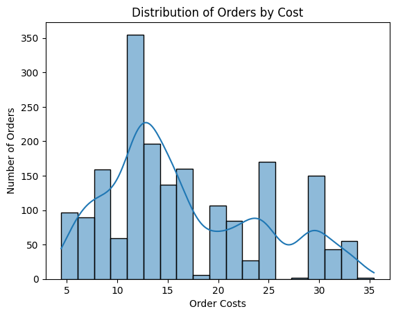

```python
# Plot distribution of order costs
sns.histplot(data=df, x="cost_of_the_order", kde=True)

# Set plot labels and title
plt.xlabel('Order Costs')
plt.ylabel('Number of Orders')
plt.title('Distribution of Orders by Cost')
```

This chart shows the distribution of costs across orders. While my initial impression based on the mean, median, max, and mins were that order costs were roughly normal, this chart shows that we have one significant mode in the $11-$15 dollar range, and two other spikes at the $25 and $30 price points, with a curious gap between them.

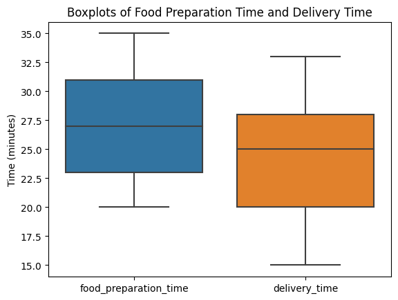

```python
#Plot boxplot distributions of food prep time and delivery time side by side
sns.boxplot(data=df[['food_preparation_time', 'delivery_time']], orient='v')
plt.ylabel('Time (minutes)')
plt.title('Boxplots of Food Preparation Time and Delivery Time')
plt.show()
```

These plots show that food preparation time is very normally distributed around a mean of ~27 minutes, with a min of 20 and max of 35 minutes, while delivery time is also somewhat normal, but with the median pulled upward, showing a slightly greater number of deliveries being in the upper half of the distribution. It's median is ~25, with a min of 15 and max of ~33, giving it a slightly greater spread than food prep time. There are no outliers in either variable.

### **Question 7**: Which are the top 5 restaurants in terms of the number of orders received?

```python
# Do value counts of how often each restaurant shows up in the data

df["restaurant_name"].value_counts()
```

```
Shake Shack                  219
The Meatball Shop            132
Blue Ribbon Sushi            119
Blue Ribbon Fried Chicken     96
Parm                          68
                            ...
Sushi Choshi                   1
Dos Caminos Soho               1
La Follia                      1
Philippe Chow                  1
'wichcraft                     1
Name: restaurant_name, Length: 178, dtype: int64
```

#### Observations: The Shake Shack has the most with 219 orders, The Meatball Shop is second with 132, Blue Ribbon Sushi is third with 119, Blue Ribbon Fried Chicken is fourth with 96, and Parm is fifth with 68 orders.

### **Question 8**: Which is the most popular cuisine on weekends?

```python
# Show the distribution of different cuisine types generally, as a comparison
print("The most popular cuisine types normally are:")
print(df["cuisine_type"].value_counts())

# Filter the cuisine type data based on weekend days
filtered_df = df[df['day_of_the_week'] == 'Weekend']

# Show the distribution of different cuisine types on weekends
print("The most popular cuisine types on the weekend are:")
print(filtered_df['cuisine_type'].value_counts())
```

```
The most popular cuisine types normally are:
American          584
Japanese          470
Italian           298
Chinese           215
Mexican            77
Indian             73
Middle Eastern     49
Mediterranean      46
Thai               19
French             18
Southern           17
Korean             13
Spanish            12
Vietnamese          7
Name: cuisine_type, dtype: int64
The most popular cuisine types on the weekend are:
American          415
Japanese          335
Italian           207
Chinese           163
Mexican            53
Indian             49
Mediterranean      32
Middle Eastern     32
Thai               15
French             13
Korean             11
Southern           11
Spanish            11
Vietnamese          4
Name: cuisine_type, dtype: int64
```

#### Observations: The most popular cuisine type on the weekends is American cuisine, which is the same as the most popular cuisine as a whole.

### **Question 9**: What percentage of the orders cost more than 20 dollars?

```python
# Total number of orders
total = len(df["cost_of_the_order"])

# Count how many orders are over the threshold value
val = 20.00
count = (df["cost_of_the_order"] > val).sum()

# Calculate and display the percentage of orders exceeding the threshold value
perc = round((count/total*100), 2)

print(f"The percentage of orders exceeding ${val:.2f} equals {perc}%")
```

```
The percentage of orders exceeding $20.00 equals 29.24%
```

#### Observations: The percentage of orders exceeding $20.00 is just shy of 30%. Since the mean is ~$16, that means this variable is somewhat right skewed, but not too strongly.

### **Question 10**: What is the mean order delivery time?

```python
# Calculate and display the mean order delivery time

mean_del_time = np.mean(df['delivery_time'])

print(f"The average order delivery time is {mean_del_time:.1f} minutes.")
```

```
The average order delivery time is 24.2 minutes.
```

#### Observations: The average order delivery time is 24.2 minutes, which is very close to the median of 25 minutes. This, along with the min of 15 and max of 33, suggests there are no outliers in the data and that the data is approximately normally distributed.

### **Question 11:** The company has decided to give 20% discount vouchers to the top 3 most frequent customers. Find the IDs of these customers and the number of orders they placed

```python
# Do a value count on customer_id and a head() to get the top 3.

df['customer_id'].value_counts().head(3)
```

```
52832    13
47440    10
83287     9
Name: customer_id, dtype: int64
```

#### Observations: The top 3 customers are 1) 52832 with 13 orders, 2) 47440 with 10 orders, and 3) 83287 with 9 orders. These are the customers to give 20% discount vouchers to.

### **Question 12**: Perform a multivariate analysis to explore relationships between the important variables in the dataset. (It is a good idea to explore relations between numerical variables as well as relations between numerical and categorical variables)

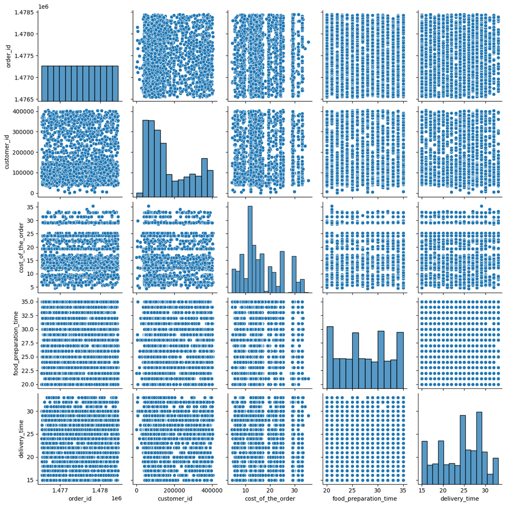

```python
# Create a pairplot to look for correlations between numeric variables in the dataset
sns.pairplot(df)
```

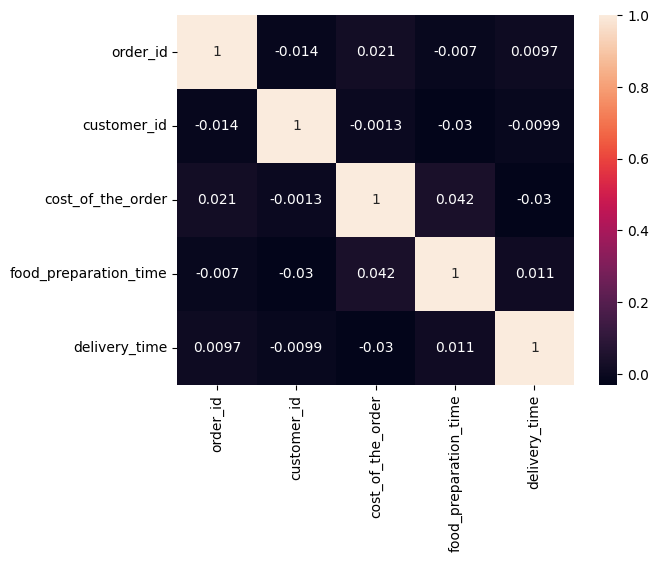

```python
# Create a heatmap of the numerical data
numeric_cols = df.select_dtypes(include=['number'])
sns.heatmap(numeric_cols.corr(), annot=True)
plt.show()
```

A first-pass review of the numeric variables in the dataset using a pairplot and a heatmap does not reveal much of value. None of these variables are well-correlated. I expected a greater correlation between Customer ID and Order Cost on the assumption that some people routinely spend more than others, but most customers only order once or twice, there isn't enough data to see such a correlation.

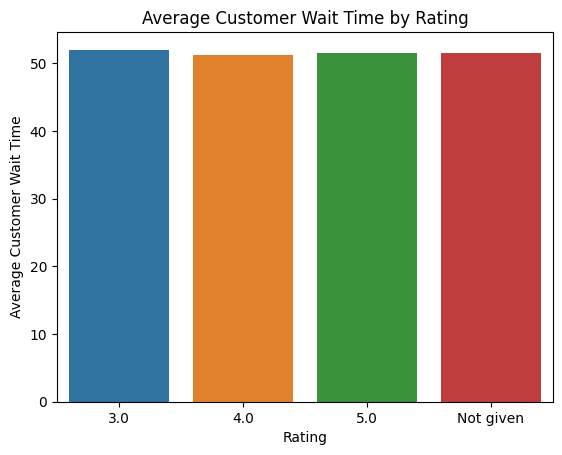

```python
# Next, I try to explore what factors affect the ratings given

# Create a bar plot to explore correlation between customer wait time and the rating that they give

# Create the 'customer_wait_time' column
df['customer_wait_time'] = df['food_preparation_time'] + df['delivery_time']

# Replace 'Not given' with NaN to handle missing values
df['rating'].replace('Not given', np.nan, inplace=True)

# Calculate the mean 'customer_wait_time' for each 'Rating' category, including NaN
rating_avg_wait_time = df.groupby('rating', dropna=False)['customer_wait_time'].mean().reset_index()

# Replace NaN with 'Not given' in the 'rating' column
rating_avg_wait_time['rating'].fillna('Not given', inplace=True)

# Create a bar plot to display the average customer wait time for each rating category
sns.barplot(data=rating_avg_wait_time, x='rating', y='customer_wait_time')
plt.xlabel('Rating')
plt.ylabel('Average Customer Wait Time')
plt.title('Average Customer Wait Time by Rating')
plt.show()
```

There appears to be no correlation whatsoever between the rating given and how long the customer had to wait for their order. The uniformity of the data is suspicious to me, and makes me wonder if I have a mistake in my calculation or analysis.

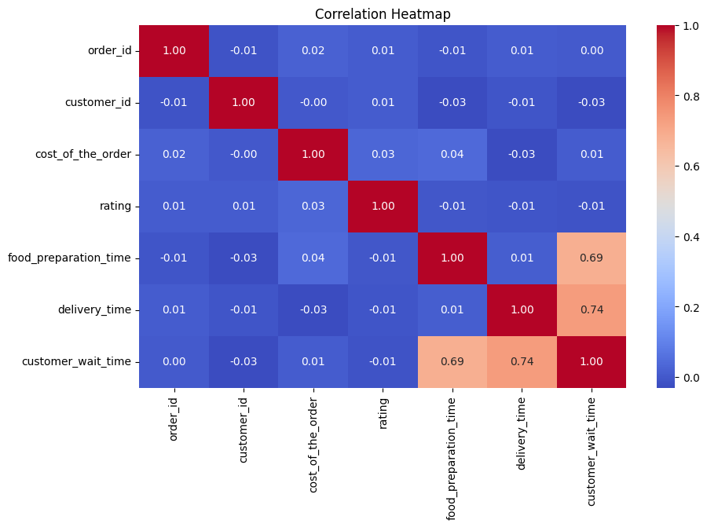

```python
# Convert rating to a numerical value and see if there is any correlation between that and the other numerical variables.

# Suppress DeprecationWarning
import warnings
warnings.simplefilter(action='ignore', category=FutureWarning)

# Replace 'Not given' with NaN in the 'rating' column to handle missing values
df['rating'].replace('Not given', np.nan, inplace=True)

# Calculate the correlation matrix
correlation_matrix = df.corr()

# Create a heatmap to visualize the correlation matrix
plt.figure(figsize=(10, 6))
sns.heatmap(correlation_matrix, annot=True, cmap='coolwarm', fmt=".2f")
plt.title('Correlation Heatmap')
plt.show()
```

Here, I converted Rating to a numerical value in order to see if it correlated with any of the other numerical variables. There is no relevant correlation.

```python
from scipy.stats import chi2_contingency

# Replace 'Not given' with NaN in the 'rating' column to handle missing values
df['rating'].replace('Not given', np.nan, inplace=True)

# Create cross-tabulations (contingency tables)
cross_tab_restaurant = pd.crosstab(df['restaurant_name'], df['rating'], dropna=False)
cross_tab_cuisine = pd.crosstab(df['cuisine_type'], df['rating'], dropna=False)

# Perform the chi-squared test for independence for both cross-tabulations
chi2_restaurant, p_restaurant, _, _ = chi2_contingency(cross_tab_restaurant)
chi2_cuisine, p_cuisine, _, _ = chi2_contingency(cross_tab_cuisine)

# Print the test results for restaurant_name
print("Chi-squared test results for 'restaurant_name':")
print(f"Chi-squared value: {chi2_restaurant}")
print(f"P-value: {p_restaurant}")

# Print the test results for cuisine_type
print("\nChi-squared test results for 'cuisine_type':")
print(f"Chi-squared value: {chi2_cuisine}")
print(f"P-value: {p_cuisine}")
```

```
Chi-squared test results for 'restaurant_name':
Chi-squared value: 305.7169301639685
P-value: 0.5580400176734136

Chi-squared test results for 'cuisine_type':
Chi-squared value: 25.08555101346046
P-value: 0.5141366637771746
```

Here, I attempt to identify any correlation between the Rating and either which Restaurant was ordered from or the cuisine type. There is insufficient evidence to reject the null hypothesis that there is no correlation. This means I have been unable to identify any pattern whatsoever as to the Rating given.

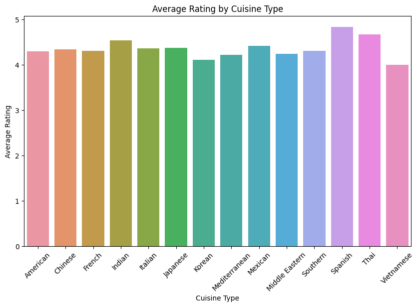

```python
# Here, I explore how rating varies by cuisine type

# Average Rating by Cuisine Type
average_rating_by_cuisine = df.groupby('cuisine_type')['rating'].mean().reset_index()

# Bar plot for average rating by Cuisine Type
plt.figure(figsize=(10, 6))
sns.barplot(data=average_rating_by_cuisine, x='cuisine_type', y='rating')
plt.xlabel('Cuisine Type')
plt.ylabel('Average Rating')
plt.title('Average Rating by Cuisine Type')
plt.xticks(rotation=45)  # Rotate x-axis labels for better readability
plt.show()
```

Here, I look at average ratings across cuisine types. There is not a wide variation in the data, which is not surprising given that we're really only looking at 3s, 4s, and 5s, but Spanish, Thai, and to a lesser extent Indian, cuisines stand out as having higher than average Ratings.

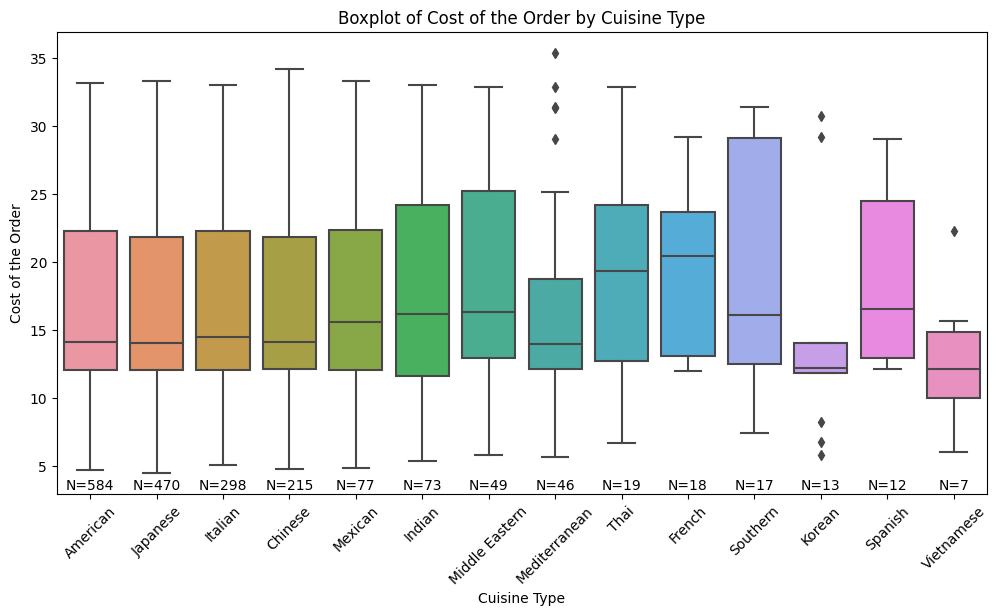

```python
# Explore how the Cost of the Order varies across Cuisine types

# Calculate the count of orders for each cuisine type
order_counts = df['cuisine_type'].value_counts().reset_index()
order_counts.columns = ['cuisine_type', 'order_count']

# Sort the order_counts DataFrame by order count in descending order so that counts and cuisine type match up
order_counts = order_counts.sort_values(by='order_count', ascending=False)

# Create a boxplot comparing order cost and cuisine type
plt.figure(figsize=(12, 6))
sns.boxplot(data=df, x='cuisine_type', y='cost_of_the_order', order=order_counts['cuisine_type'])
plt.xlabel('Cuisine Type')
plt.ylabel('Cost of the Order')
plt.title('Boxplot of Cost of the Order by Cuisine Type')
plt.xticks(rotation=45)

# Annotate the boxplot with order counts
for index, row in order_counts.iterrows():
    median_position = df[df['cuisine_type'] == row['cuisine_type']]['cost_of_the_order'].median()
    plt.annotate(f'N={row["order_count"]}', xy=(index, 3), ha='center', va='bottom')

plt.show()
```

### **Question 13:** The company wants to provide a promotional offer in the advertisement of the restaurants. The condition to get the offer is that the restaurants must have a rating count of more than 50 and the average rating should be greater than 4. Find the restaurants fulfilling the criteria to get the promotional offer

```python
# Convert numeric ratings to integers (leaving 'Not given' values unchanged)
df['rating'] = pd.to_numeric(df['rating'], errors='coerce')

# Get rid of 'Not given' values for ratings, as I assume these don't count towards the restaurants' rating totals.
filtered_orders = df.dropna(subset=['rating'])

# Calculate the count of ratings for each restaurant
rating_counts = filtered_orders.groupby('restaurant_name')['rating'].count()

# Filter out restaurants with 50 or fewer numeric ratings and display those with more than 50
eligible_restaurants = rating_counts[rating_counts > 50].index.tolist()

num_restaurants = len(eligible_restaurants)
print(f"There are {num_restaurants} restaurants with more than 50 'Not given' ratings.")

# Calculate the mean rating for each eligible restaurant
average_ratings = filtered_orders[filtered_orders['restaurant_name'].isin(eligible_restaurants)].groupby('restaurant_name')['rating'].mean()

print(f"These restaurants are \n{eligible_restaurants}")
print(f"Their average ratings are \n {average_ratings}")

print(f"Since they all have an average rating greater than 4, they are all eligible for the promotional offer.")
```

```
There are 4 restaurants with more than 50 'Not given' ratings.
These restaurants are
['Blue Ribbon Fried Chicken', 'Blue Ribbon Sushi', 'Shake Shack', 'The Meatball Shop']
Their average ratings are
 restaurant_name
Blue Ribbon Fried Chicken    4.328125
Blue Ribbon Sushi            4.219178
Shake Shack                  4.278195
The Meatball Shop            4.511905
Name: rating, dtype: float64
Since they all have an average rating greater than 4, they are all eligible for the promotional offer.
```

### **Question 14:** The company charges the restaurant 25% on the orders having cost greater than 20 dollars and 15% on the orders having cost greater than 5 dollars. Find the net revenue generated by the company across all orders

```python
# Determine the threshold values
upper_val = 20.00
lower_val = 5.00

# Calculate the total order amounts in each bucket
total1 = round(df[(df["cost_of_the_order"] > lower_val) & (df["cost_of_the_order"] <= upper_val)]['cost_of_the_order'].sum(), 2)
total2 = round(df[df['cost_of_the_order'] > upper_val]['cost_of_the_order'].sum(), 2)

# Calculate the revenue generated from each bucket
revenue1 = total1 * .15
revenue2 = total2 * .25

# Calculate total net revenue
total_net_rev = revenue1 + revenue2

# Display results
print(f"There was a total value of ${total1} in orders greater than ${lower_val:.2f} and less than or equal to ${upper_val:.2f}, which at a 15% rate yielded a revenue of ${revenue1:.2f}.")
print(f"There was a total value of ${total2} in orders greater than ${upper_val:.2f}, which at a 25% rate yielded a revenue of ${revenue2:.2f}.")
print(f"This produced a total net revenue of ${total_net_rev:.2f} over this time period.")
```

```
There was a total value of $16517.17 in orders greater than $5.00 and less than or equal to $20.00, which at a 15% rate yielded a revenue of $2477.58.
There was a total value of $14754.91 in orders greater than $20.00, which at a 25% rate yielded a revenue of $3688.73.
This produced a total net revenue of $6166.30 over this time period.
```

#### Observations: There was a total value of $16517.17 in orders greater than $5.00 and less than or equal to $20.00, which at a 15% rate yielded a revenue of $2477.58. There was a total value of $14754.91 in orders greater than $20.00, which at a 25% rate yielded a revenue of $3688.73. This produced a total net revenue of $6166.30 over this time period.

### **Question 15:** The company wants to analyze the total time required to deliver the food. What percentage of orders take more than 60 minutes to get delivered from the time the order is placed? (The food has to be prepared and then delivered)

```python
# Create new temporary column combining food preparation time and delivery time
df["total_time"] = df["delivery_time"] + df["food_preparation_time"]

# Find the total number of orders
total = len(df["total_time"])

# Count how many orders are over the threshold value of 60 minutes
val = 60
count = (df["total_time"] > val).sum()

# Calculate and display the percentage of orders exceeding the threshold value
perc = round((count/total*100), 2)
print(f"The total number of orders placed is {total} and the number of orders over {val} minutes is {count}.")
print(f"Therefore, the percentage of orders exceeding {val} minutes equals {perc:.1f}%")
```

```
The total number of orders placed is 1898 and the number of orders over 60 minutes is 200.
Therefore, the percentage of orders exceeding 60 minutes equals 10.5%
```

#### Observations: The total number of orders placed is 1898 and the number of orders over 60 minutes is 200.

#### Therefore, the percentage of orders exceeding 60 minutes equals 10.5%

### **Question 16:** The company wants to analyze the delivery time of the orders on weekdays and weekends. How does the mean delivery time vary during weekdays and weekends?

```python
# Divide the data set into weekends and weekdays
weekends = df[df['day_of_the_week'] == 'Weekend']
weekdays = df[df['day_of_the_week'] == 'Weekday']

# Calculate the mean delivery time for both weekends and weekdays
weekend_delivery_mean = np.mean(weekends['delivery_time'])
weekday_delivery_mean = np.mean(weekdays['delivery_time'])

# For comparison, calculate the overall mean delivery time across the week
avg_del_time_overall = np.mean(df["delivery_time"])

# To get contextual information about the volume of deliveries on weekends and weekdays
weekend_dels = len(weekends)
weekday_dels = len(weekdays)

# Display relevant results and contextual information
print(f"The mean delivery time on weekdays is {weekday_delivery_mean:.1f} and the mean delivery time on weekends is {weekend_delivery_mean:.1f}.")
print(f"Contrast that with the total average delivery time across the week, which is {avg_del_time_overall:.1f}.")
print(f"The total number of deliveries on weekends is {weekend_dels} and the total number of weekday deliveries is {weekday_dels}.")
```

```
The mean delivery time on weekdays is 28.3 and the mean delivery time on weekends is 22.5.
Contrast that with the total average delivery time across the week, which is 24.2.
The total number of deliveries on weekends is 1351 and the total number of weekday deliveries is 547.
```

### Recommendations:

- Feedback and Rating System: Encourage customers to leave ratings and reviews by offering incentives or discounts. This will provide valuable insights into customer satisfaction and areas for improvement.
- Weekend Promotions: Focus marketing efforts, discounts, and promotions on weekends to capitalize on increased order volume during that time. Conversely, one might target weekdays for growth, but the increased delivery times during weekdays will need to be considered.
- Customer Loyalty Programs: Implement customer loyalty programs to reward repeat customers and encourage them to order more frequently.
- Cuisine Expansion: Consider expanding the offerings of popular or highly-rated cuisines, or explore partnerships with additional restaurants that offer in-demand cuisines.
- Price Point Analysis: Analyze customer preferences and behaviors at different price points (specifically, $25 and $30) to tailor marketing strategies and menu offerings accordingly.
- Partnering with the most popular restaurants may be the most effective way to increase order volume.